# Функції в Python

Більше тут https://pythonguide.rozh2sch.org.ua/#_%D1%84%D1%83%D0%BD%D0%BA%D1%86%D1%96%D1%97

[figure not shown]

## Що таке фунції та навіщо вони потрібні?

### До цього моменту ми завжди писали наші програми по інструкціям (рядкам) зверху вниз.

### Наприклад: в нас є два числа: десять та чотири. Потрібно їх додати, потім поділити на 100, потім помножити на 25.

### Стандартно ми б писали це все по порядку

```python
first_number = 10
second_number = 4
sum_of_numbers = first_number + second_number
divide_on_hundred = sum_of_numbers / 100
result = divide_on_hundred * 25
print(result)
```

```
3.5000000000000004
```

### А тепер уявимо, що вам дали таку саму задачу, але з різними числами: 2 і 3, 5 і 6, 3 і 6 і так далі

```python
first_number_1 = 2
second_number_1 = 3
sum_of_numbers_1 = first_number_1 + second_number_1
divide_on_hundred_1 = sum_of_numbers_1 / 100
result_1 = divide_on_hundred_1 * 25
print(result_1)
first_number_2 = 5
second_number_2 = 6
sum_of_numbers_2 = first_number_2 + second_number_2
divide_on_hundred_2 = sum_of_numbers_2 / 100
result_2 = divide_on_hundred_2 * 25
print(result_2)
first_number_3 = 3
second_number_3 = 6
sum_of_numbers_3 = first_number_3 + second_number_3
divide_on_hundred_3 = sum_of_numbers_3 / 100
result_3 = divide_on_hundred_3 * 25
print(result_3)
```

```
1.25
2.75
2.25
```

### Ура, ми це зробили, але погодьтесь, що виглядає це дивно. Ми зробили одну і ту саму послідновність дій 3 рази підряд. Функції придумані для того, щоб ця послідовність дій була однією функцією, та могла бути використана багато разів.

### Наведемо приклад виконання цього завдання з функцією

# Як написати фунцію?

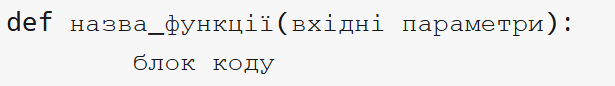

```python
def functionForTwoNumbers(first_num,second_num):
    sum_of_numbers = first_num + second_num
    divide_on_hundred = sum_of_numbers / 100
    result = divide_on_hundred * 25
    print(result)

# викликаємо фукнцію, написавши її назву, та передавши в дужки числа
functionForTwoNumbers(2,3)
functionForTwoNumbers(5,6)
functionForTwoNumbers(3,6)
```

```
1.25
2.75
2.25
```

### Погодьтесь, що з використанням функції кількість коду зменшилась

### Наші значення передаються в функцію як параметри

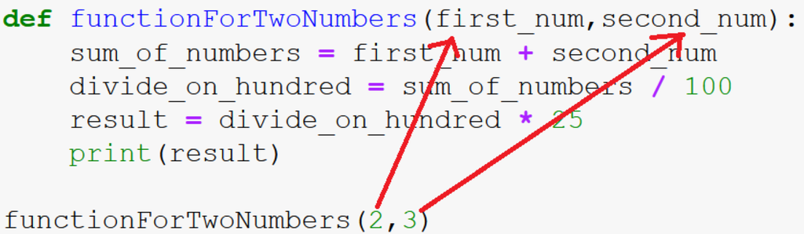

### Також функції можуть бути без параметрів (в дужках може не бути змінних)

```python
def sayHello():
    print("Hello")


sayHello()
```

```
Hello
```

### Приклад 1: функція, яка віднімає два числа

```python
def diff(a,b):
    c = a - b
    print(c)

diff(3,1)
```

```
2
```

### А як записати результат функції в змінну? За допомогою слова return

```python
def diff(a,b):
    c = a - b
    return c

c = diff(3,1)
print(c)
```

```
2
```

[figure not shown]

# Завдання 1: Написати функцію, яка виводить ваше ім'я на консоль. Викликати її та перевірити чи вона працює

# (1 бал)

# ------------------------------------------------------------------------------------

# Завдання 2: Написати калькулятор на Python, використовуючи функції. Вам потрібно створити різні функції для додавання, віднімання, ділення, множення. Протестувати ваші функції на числах 5 і 2. Результати арифметичних дій вивести на консоль (2 бали)

# ------------------------------------------------------------------------------------

### Функції можна викликати в різних ситуаціях та фрагментах коду, наведемо приклад

```python
def add(a,b):
    c = a + b
    return c

print("Чи хочете ви додати два числа? Введіть номер опції")
print("1.Так")
print("2.Ні")
option = input()
if option == "1":
    print("перше число: ")
    first_num = int(input())
    print("друге число: ")
    second_num = int(input())
    result = add(first_num, second_num)
    print(result)
else:
    print("GoodBye")
```

```
Чи хочете ви додати два числа? Введіть номер опції
1.Так
2.Ні
1
перше число:
2
друге число:
3
5
```

# Завдання 3: До програми з завдання номер 2 додати меню вибору арифметичної дії та введення чисел з клавіатури

# (2 бали)

# ------------------------------------------------------------------------------------

# Задача: Мама пішла в супермаркет та побачила, що там є акція на парну кількість товарів в корзині.

# Завдання 4: Написати функцію, яка перевіряє чи число є парним. Цю функцію потрібно перевірити на числі, яке вводиться з клавіатури, якщо воно парне, то вивести повідомлення "Акція діє", якщо ні, то "Акція не діє"

# (2 бали)

### Подивимся, чи функції можуть приймати змінні різних типів

### Список

```python
def print_list(myList):
    print("Count of elements: ", len(myList))
    print(my_list)

family = ["Гомер", "Барт", "Ліза", "Мардж", "Мегі"]
printList(family)
```

[output not shown]

### Стрічки

```python
def length_of_name(name):
    print("Count of letters in name: ", len(name))

length_of_name("Гомер")
```

```
Count of letters in name:  5
```

# Завдання 5: Написати функцію, яка виводить на консоль елементи списку в циклі. Перевірте функцію, використовуючи список ["Ярослав", "Богдан", "Катя"]

# (1 бал)

# Завдання 6: Написати функцію, яка додає новий елемент в список. До списку з минулого завдання додати "Євген"

# (1 бал)

# Завдання 7: Написати функцію, яка перевіряє чи в списку є ім'я "Євген" (1 бал)